# Clustering à la PCWAG

```r
set.seed(1234)

# Used packages
require(dplyr)
require(readr)
library(tidyverse, quietly = TRUE)

# Models
require(VGAM)
require(ccube)
require(mclust)
require(fpc)
require(matrixStats)

# Plots
library(patchwork)
require(ggplot2)
require(cowplot)

# Weme source code
source("./weme.R")
```

## Example dataset

We generated a simulated dataset assuming:

- a beta binomial density;
- coverage $45$;
- overdispersion $\rho~0.019$.
- a mnoclonal tumour, i.e., with just the clonal cluster;
- $80\%$ purity.

All these values are well representative of the PCAWG data quality for the right tail of overdispersion values.

```r
# Parameters
COVERAGE <- 45
N <- 10000
PURITY  <-  0.8
```

Synthetic read-counts.

```r
simulate_data = function(overdispersion = 0.01,
                         N = 1000,
                         coverage = rpois(N, 45), seed = 3, purity = 1)
{
  data.frame(
    DP = coverage,
    NV = VGAM::rbetabinom(
      n = N,
      size = coverage,
      prob = 0.5 * purity,
      rho = overdispersion
    )
  ) %>%
    mutate(VAF = NV / DP)
}
```

```r
# Poisson-distributed coverage

rhos <- readr::read_tsv("../../rho_selected_cases.tsv")
# we get a tail value
overdispersion <- rhos$rho %>% quantile(0.95)

N = N
coverage = rpois(N,lambda = COVERAGE) %>% round()

input = simulate_data(overdispersion = overdispersion,
                      N = N,
                      coverage = coverage, seed = seed, purity = PURITY)
input$chr = 1
input$position = sample.int(n = 1e8, replace = F, size = nrow(input))
input$overdispersion = overdispersion
```

Synthetic data plots

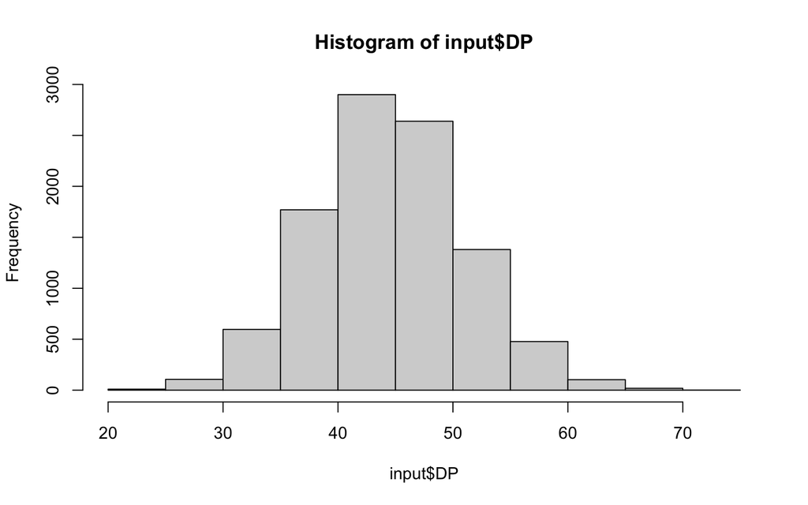

```r
hist(input$DP)
```

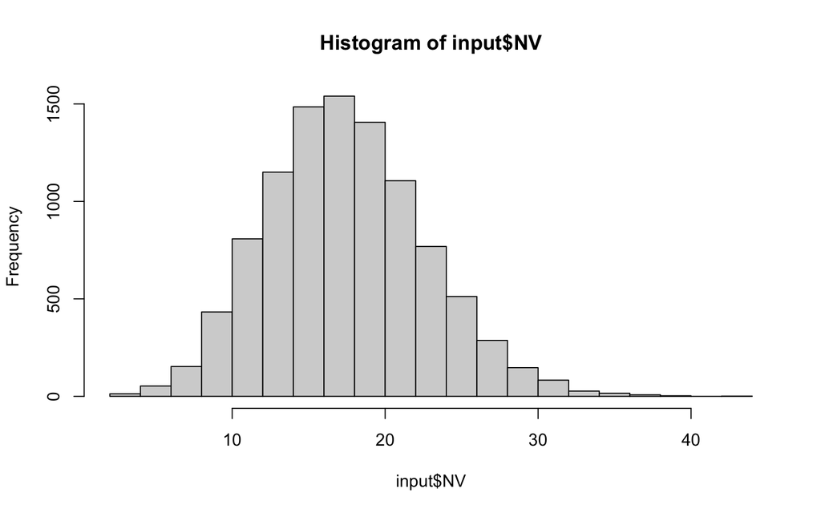

```r
hist(input$NV)
```

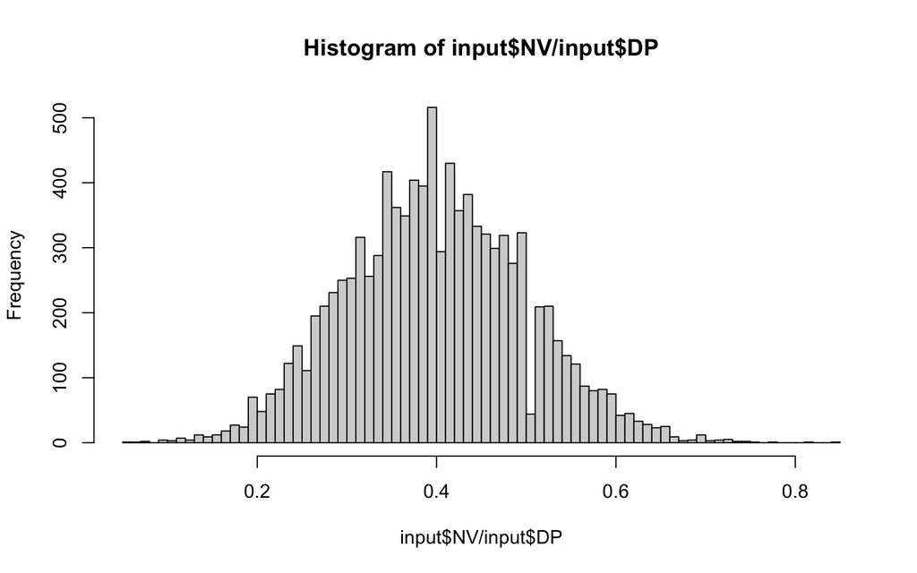

```r
hist(input$NV/input$DP, breaks = 60) # VAF
```

# Ccube analysis (normal-binomial, variational)

We run ccube as in the vignette with 5 repetitions

```r
numOfClusterPool = 1:6
numOfRepeat = 5

# Format
ccube_inp <- data.frame(
  major_cn = 1,
  minor_cn = 1,
  total_cn = 2,
  purity = PURITY,
  normal_cn = 2,
  mutation_id = paste(input$chr, input$position, sep = "_"),
  var_counts = input$NV,
  ref_counts = input$DP - input$NV,
  total_counts = input$DP
) %>% as_tibble()

# Fit
results_ccube <- RunCcubePipeline(
  ssm = ccube_inp,
  numOfClusterPool = numOfClusterPool,
  numOfRepeat = numOfRepeat,
  runAnalysis = T,
  runQC = T, multiCore = T

)

# Save results
save(results_ccube, file = "results_ccube.rda")
```

Inspect results - standard Ccube visualisation. Recall that there should be only 1 single-cluster in this deconvolution.

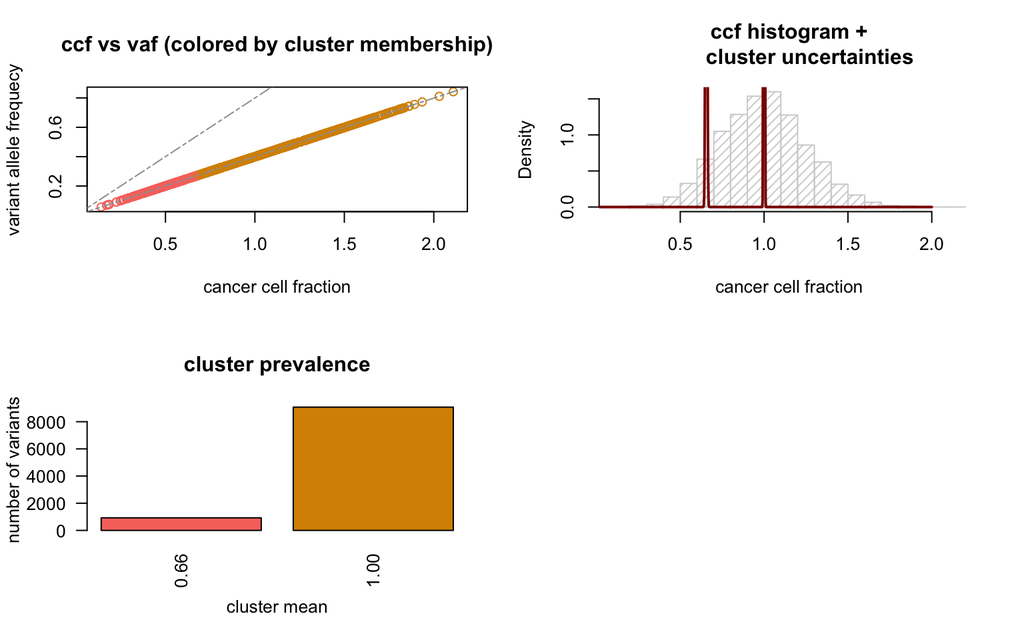

```r
load("results_ccube.rda")

MakeCcubeStdPlot(ssm = results_ccube$ssm, res = results_ccube$res)
```

# DPClust analysis (binomial, Monte Carlo)

Prepare inputs.

```r
dir.create("dpclust_input", showWarnings = FALSE)

data.frame(
  chr = input$chr,
  end = input$position,
  Reference_Allele = "A", # Made up, do not affect results
  Tumor_Seq_Allele2 = "T",
  mut.count  = input$NV,
  WT.count = input$DP - input$NV,
  subclonal.CN   = 2,
  mutation.copy.number   = 1,
  subclonal.fraction     = 1,
  no.chrs.bearing.mut   = 1
) %>%
  readr::write_tsv(., "dpclust_input/sample0_input.txt")

data.frame(
  sample = "sample0",
  subsample = "01",
  datafile = "./sample0_input.txt",
  cellularity = PURITY
) %>%
  readr::write_tsv(., "dpclust_input/sample0.txt")
```

For DPClust we use the pipeline that can be found in the package, it is also available as a docker image. The code below is not run by this markdown.

```bash
source ~/.bashrc

mkdir -p output_dpclust
cd dpclust/inst/example

module load R/4.1.0

R --vanilla --slave -q -f dpclust_pipeline.R --args -r 1 -d ../../../dpclust_input/ -o ../../../output_dpclust -i ../../../dpclust_input/sample0.txt
```

Assemble results, and print outputs.

```r
cluster_composition_dpclust <-
  readr::read_tsv(
    "output_dpclust/sample0_DPoutput_2000iters_1000burnin_seed123/sample0_2000iters_1000burnin_bestClusterInfo.txt",
    col_types = cols()
  )

print(cluster_composition_dpclust)
```

# Pyclone-VI analysis (beta-binomial, variational)

Create inputs.

```r
dir.create("pyclone_input", showWarnings = F)

data.frame(
  mutation_id = paste0("S_", 1:length(input$DP)), # indifferent
  sample_id = "example",
  alt_counts     = input$NV,
  ref_counts = input$DP - input$NV,
  normal_cn  = 2,
  major_cn   = 1,
  minor_cn  = 1,
  tumour_content = PURITY
) %>%
  readr::write_tsv(., "pyclone_input/sample0_input.tsv")
```

Fit is run through the conda environment previously created.

```bash
source /home/salvatore.milite/miniconda3/etc/profile.d/conda.sh

conda activate pyclone-vi

mkdir output_pyclone

pyclone-vi fit -i pyclone_input/sample0_input.tsv -o output_pyclone/example.h5 -c 40 -d beta-binomial -r 10

pyclone-vi write-results-file -i output_pyclone/example.h5 -o output_pyclone/example.tsv
```

# Mclust + merging (gaussian + post hoc correction)

The CCF calculation here is trivial (no need for Bayclone)

```r
ccf <- input$VAF * 2
```

We then run mclust with the same parameters used in the Dentro paper and correct the result with `mergenormals`

```r
library(mclust)

res_mclust <- Mclust(ccf, G = 1:8)

summary(res_mclust)
```

```r
library(fpc)

dir.create("mclust_out")

if(res_mclust$G > 1){

  res_mclust_merged <- mergenormals(ccf,res_mclust, method = "ridge.uni")

  sm <-  summary(res_mclust_merged)

  data.frame(id = 1:length(sm$clusternumbers), n_ssm = sm$clustering %>%  table() %>%  as.numeric(), loc = sm$muarray) %>% readr::write_tsv("mclust_out/mclust_subclonal_structure.tsv")

  data.frame(clusters = sm$clustering) %>% readr::write_tsv("mclust_out/mclust_clusters.tsv")

  data.frame(id = 1:length(sm$clusternumbers), n_ssm = sm$clustering %>%  table() %>%  as.numeric(), loc = sm$muarray)

} else {

  data.frame(id = 1:length(res_mclust$G), n_ssm = res_mclust$classification %>%  table() %>%  as.numeric(), loc = res_mclust$parameters$mean) %>% readr::write_tsv("mclust_out/mclust_subclonal_structure.tsv")

  data.frame(clusters = res_mclust$classification) %>% readr::write_tsv("mclust_out/mclust_clusters.tsv")

  data.frame(id = 1:length(res_mclust$G), n_ssm = res_mclust$classification %>%  table() %>%  as.numeric(), loc = res_mclust$parameters$mean)

}
```

# CliP (Binomial)

As the author propose a `bootstrap log-likelihood ratio test to select the penalizing parameter` but the code is not released in the official GitHub, we use BIC to select the best model as suggested two lines above.

```r
dir.create("clip_input", showWarnings = FALSE)

data.frame(
  chromosome_index = input$chr,
  position = input$position,
  alt_count  = input$NV,
  ref_count = input$DP - input$NV
) %>%
  readr::write_tsv(., "clip_input/sample.snv.txt")

data.frame(
  chromosome_index = 1,
  start_position = 1,
  end_position = max(input$position) + 10000,
  major_cn = 1,
  minor_cn = 1,
  total_cn = 2
) %>%
  readr::write_tsv(., "clip_input/sample.cna.txt")

as.data.frame(PURITY) %>%
  readr::write_tsv(., "clip_input/sample.purity.txt", col_names = FALSE)
```

We use the default lambdas as there is no indication in the paper

```bash
source /home/salvatore.milite/.bashrc

conda activate clip

module load R/4.1.0

cd CliP

python3 run_clip_main.py ../clip_input/sample.snv.txt ../clip_input/sample.cna.txt ../clip_input/sample.purity.txt
```

Implement BIC

```r
calculate_BIC <- function(df, inp){
  library(matrixStats)

  pi <- df$num_SNV / sum(df$num_SNV)
  locs <- df$cellular_prevalence

  npar <- length(locs) + length(pi) - 1

  lk <- sapply(locs, function(loc) dbinom(inp$NV,prob = loc/2, size = inp$DP, log = T)) + log(pi)

  lk <-  apply(lk, 1, logSumExp) %>%  sum()

  NLL2 <- -lk * 2
  PEN <- log(nrow(df)) * npar
  return(NLL2 + PEN)

}


collapse_clusters <- function(x, e = 0.01) {

  copy <- x
  pi <- x$num_SNV / sum(x$num_SNV)
  idx_to_collapse <- which(pi < e)
  idx_to_retain <- which(pi >= e)
  for (idx in idx_to_collapse){
    nearest_cluster <- which.min(abs(x$cellular_prevalence[idx] - x$cellular_prevalence[idx_to_retain]))
    copy$num_SNV[idx_to_retain[nearest_cluster]] <- copy$num_SNV[idx_to_retain[nearest_cluster]] + x$num_SNV[idx]
  }

  return(copy[idx_to_retain,])

}
```

```r
res_dir <- "./CliP/sample_id/final_result/"

dir.create("clip_output")

files <- list.files(res_dir, full.names = T) %>% grep(pattern = "subclonal_structure", value = T)

dfs <- lapply(files, readr::read_tsv)

dfs <- lapply(dfs, function(x) collapse_clusters(x, e = 0.01) )

BICs <- lapply(dfs, function(df) calculate_BIC(df, input))

best_model_idx <- unlist(BICs) %>%  which.min

(best_model_clip <- dfs[[best_model_idx]])

best_model_clip %>% readr::write_tsv("clip_output/clip_subclonal_structure.tsv")

best_lamda <- files[best_model_idx] %>%  stringi::stri_match(., regex = "lam.*")

best_ass <- readr::read_tsv(paste0(res_dir, "mutation_assignments_", best_lamda))

best_ass %>% readr::write_tsv("clip_output/clip_clusters.tsv")
```

# CTPsingle

```r
dir.create("ctp_input", showWarnings = FALSE)

data.frame(
  Chromosome = input$chr,
  Position = input$position,
  Mutant = "A",
  Reference = "T",
  Mcount     = input$NV,
  Rcount = input$DP - input$NV,
  Multiplier = 2,
  Gender = "Female"
) %>%
  readr::write_tsv(., "ctp_input/sample.snv.txt")
```

```bash
source /home/salvatore.milite/.bashrc

module load R/4.1.0

mkdir ctp_output

CTPsingle/CTPsingle.R -f ./ctp_input/sample.snv.txt -o ./ctp_output/example_PCAWG_ctp -m ./CTPsingle/GammaAdjMatrices
```

# PhylogicNDT

```r
dir.create("phylogic_input", showWarnings = FALSE)

data.frame(
  Hugo_Symbol = "",
  Chromosome = input$chr,
  Start_position = input$position,
  Reference_Allele = "A", # Made up, do not affect results
  Tumor_Seq_Allele2 = "T",
  t_alt_count    = input$NV,
  t_ref_count = input$DP - input$NV,
  local_cn_a1    = 1,
  local_cn_a2    = 1
) %>%
  readr::write_tsv(., "phylogic_input/sample0_input.txt")

data.frame(
  sample = "sample0",
  maf_fn = "./phylogic_input/sample0_input.txt",
  seg_fn = "",
  cellularity = PURITY,
  timepoint = 0
) %>%
  readr::write_tsv(., "phylogic_input/sample0.sif")
```

```bash
source /home/salvatore.milite/miniconda3/etc/profile.d/conda.sh

conda activate phylogic

./PhylogicNDT/PhylogicNDT.py Cluster -i sample0  -sif phylogic_input/sample0.sif --maf_input_type calc_ccf
```

```bash
mkdir phylogic_output

mv sample0*  phylogic_output
```

# PhyloWGS

We undersample the dataset for efficiency reasons

```r
dir.create("wgs_input", showWarnings = FALSE)

# subsample for efficiency reasons
data.frame(
  id = paste0("s", 0:(nrow(input) - 1)),
  gene = paste0("gene",  0:(nrow(input) - 1)),
  a = input$DP - input$NV,
  d  = input$DP,
  mu_r = 0.999,
  mu_v = 0.499
) %>% filter(row_number() <= 1:500) %>%
  readr::write_tsv(., "wgs_input/ssm_data.txt")
```

```bash
source /home/salvatore.milite/.bashrc

conda activate phylowgs

#no copy number events in our simple simulation
rm -rf wgs_output

touch wgs_input/cnv_data.txt

mkdir wgs_output

cd phylowgs

python multievolve.py --num-chains 4 --ssms ../wgs_input/ssm_data.txt --cnvs ../wgs_input/cnv_data.txt --output-dir ../wgs_output
```

```bash
source /home/salvatore.milite/.bashrc

conda activate phylowgs

cd wgs_output

python ../phylowgs/write_results.py example ./trees.zip example.summ.json.gz example.muts.json.gz example_data.mutass.zip
```

We apply the same filtering as in Dentro paper

```r
library(R.utils)

gunzip("wgs_output/example.summ.json.gz")
```

```r
library(jsonlite)

wgs_inp <- readr::read_tsv("wgs_input/ssm_data.txt")

lks <- jsonlite::read_json("wgs_output/example.summ.json")

summary_trees <- lapply(lks$trees, function(s) {
  res <- s$populations %>% as.data.frame() %>% matrix(ncol = 3, byrow = T) %>%  as.data.frame()
  res <- res[-1,-2]
  names(res) <- c("n_ssm", "loc")
  res$id <- paste0(1:nrow(res))
  return(res %>% mutate(n_ssm = as.integer(n_ssm), loc = as.numeric(loc)))
})


# as a proxy of polyclonality we remove everything branching (considering it is irrealistic in our setting to have a branching population)

is_branching <- sapply(lks$trees, function(t) t$branching_index > 0)

summary_trees <- summary_trees[!is_branching]


# remove superclonal cluster, this is a samplification of the original process

has_supercluster <-  sapply(summary_trees, function(sm) sm$n_ssm[2] > sm$n_ssm[1] * 3)

summary_trees <- summary_trees[!has_supercluster]

# MAP K

nK <-  table(sapply(summary_trees, function(sm) nrow(sm)))

MAP_K <- names(nK)[which.max(nK)]

which_K <- sapply(summary_trees, function(sm) nrow(sm) == MAP_K)

summary_trees_K <- summary_trees[which_K]

final_struct_wgs <- summary_trees_K %>%  do.call(rbind,.) %>%  group_by(id) %>%  summarize(n_ssm = mean(n_ssm) %>%  round(), loc = mean(loc))

final_struct_wgs %>%  readr::write_tsv(., file = "wgs_output/final_struct_wgs.tsv")
```

# Sclust

```r
NUC <- c("A", "C", "G", "T")

comp <- function(n) {
  if(n == "A") return("T")
  if(n == "T") return("A")
  if(n == "C") return("G")
  if(n == "G") return("C")
}

comp <- Vectorize(comp)

dir.create("sclust_input", showWarnings = FALSE)

data.frame(Mut_ID = paste0("example_",paste0("chr",input$chr), "_SNM:", input$position)) %>% mutate(

  Chr = paste0("chr",input$chr),
  Position = input$position,
  Wt = sample(NUC, replace = F, size = nrow(input)), # Made up
  Mu = comp(Wt),
  Af_obs = input$VAF,
  Coverage   = input$DP,
  AF_exp = PURITY * 0.5,
  Mut_Copies = 1,
  Mut_Copies_Raw = rnorm(nrow(input), mean = 1, sd = 0.05),
  Is_Subclonal_CN = 0,
  iCN = 2,
  # good approximation to the real one
  P_Is_Clonal = apply(input, 1,  function(i) binom.test(i["NV"], n =  i["DP"], p = PURITY * 0.5)$p.value)


) %>%
  readr::write_tsv(., "sclust_input/example_muts_expAF.txt")
```

```bash
source /home/salvatore.milite/.bashrc


cd sclust_input

../Sclust/bin/Sclust cluster -i example
```

```bash
source /home/salvatore.milite/.bashrc

mkdir sclust_output

mv sclust_input/example_mclusters.txt sclust_input/example_cluster_assignments.txt sclust_output
```

# SVclone

```r
dir.create("svclone_input", showWarnings = FALSE)

data.frame(
  chrom = input$chr,
  pos = input$position,
  gtype = "1,1,1.0",
  var = input$NV,
  ref = input$DP - input$NV
) %>%
  readr::write_tsv(., "svclone_input/example_filtered_snvs.tsv")



data.frame(
  sample = "example",
  purity = PURITY,
  ploidy = 2
) %>%
  readr::write_tsv(., "svclone_input/pp_file.txt")
```

```bash
source /home/salvatore.milite/.bashrc

module load R/4.1.0

conda activate svclone

svclone cluster -s example --snv svclone_input/example_filtered_snvs.tsv --purity_ploidy svclone_input/pp_file.txt --out svclone_output
```

# Subclonal structure formatting

```r
merge_under <- function(x, e = 0.01) {
  if(nrow(x) == 1) return(x)
  copy <- x
  pi <- x$n_ssms / sum(x$n_ssms)
  idx_to_collapse <- which(pi < e)
  idx_to_retain <- which(pi >= e)
  for (idx in idx_to_collapse){
    nearest_cluster <- which.min(abs(x$proportion[idx] - x$proportion[idx_to_retain]))
    copy$n_ssms[idx_to_retain[nearest_cluster]] <- copy$n_ssms[idx_to_retain[nearest_cluster]] + x$n_ssms[idx]
  }

  return(copy[idx_to_retain,])
}
```

**Method 1: CCube.**

```r
dir.create("example_simulated", showWarnings = F)

# Method 1 - Ccube
dir.create("example_simulated/method1", showWarnings = F)

load("results_ccube.rda", verbose = T)

results_ccube$ssm$cluster_id <- results_ccube$res$label
ccube_sc = results_ccube$ssm %>%
  group_by(cluster_id) %>%
  summarise(
    n_ssms = n(),
    proportion = ccube_ccf_mean %>%  unique()
    ) %>%
  rename(cluster = cluster_id) %>%
  select(cluster, n_ssms, proportion) %>%
  mutate(proportion = proportion * PURITY)

readr::write_tsv(
  "example_simulated/method1/example_subclonal_structure.txt",
  x = ccube_sc %>%
    merge_under()  %>%
    arrange(-proportion) %>%
    mutate(cluster = 1:length(cluster))
  )
```

**Method 2: DPClust**

```r
dir.create("example_simulated/method2", showWarnings = F)

cluster_composition_dpclust <- readr::read_tsv("output_dpclust/sample0_DPoutput_2000iters_1000burnin_seed123/sample0_2000iters_1000burnin_bestClusterInfo.txt", col_types = readr::cols())

## dpclust apparently returns the location in terms of total tumour cells so we multiply it by purity
dpclust_sc <-  cluster_composition_dpclust %>%
  rename(
    cluster = cluster.no,
    proportion = location,
    n_ssms = no.of.mutations) %>%
  mutate(proportion= proportion * PURITY) %>%
  select(cluster, n_ssms, proportion)

readr::write_tsv(
  "example_simulated/method2/example_subclonal_structure.txt",
  x = dpclust_sc %>%
    merge_under() %>%
    arrange(-proportion) %>%
    mutate(cluster = 1:length(cluster))
  )
```

**Method 3: Pyclone-VI**

```r
dir.create("example_simulated/method3", showWarnings = F)

pyclone_out <-
  readr::read_tsv("output_pyclone/example.tsv", col_types = cols()) %>%
  group_by(cluster_id, cellular_prevalence) %>%
  summarize(n_ssms = n())

pyclone_sc <- pyclone_out %>%
  rename(cluster = cluster_id, proportion = cellular_prevalence) %>%
  select(cluster, n_ssms, proportion) %>%
  mutate(proportion = proportion * PURITY)

readr::write_tsv(
  "example_simulated/method3/example_subclonal_structure.txt",
  x = pyclone_sc %>%
    merge_under() %>%
    arrange(-proportion) %>%
    mutate(cluster = 1:length(cluster))
)
```

**Method 4: Mclust**

```r
dir.create("example_simulated/method4", showWarnings = F)

mclust_out <-
  readr::read_tsv("mclust_out/mclust_subclonal_structure.tsv", col_types = cols())

mclust_out <- mclust_out %>%
  rename(cluster = id, n_ssms = n_ssm, proportion = loc)

readr::write_tsv(
  "example_simulated/method4/example_subclonal_structure.txt",
  x = mclust_out %>%
    merge_under %>%
    arrange(-proportion)

)
```

**Method 5: CliP**

```r
dir.create("example_simulated/method5", showWarnings = F)

clip_out <-
  readr::read_tsv("clip_output/clip_subclonal_structure.tsv", col_types = cols())

clip_out <- clip_out %>%
  rename(cluster = cluster_index, n_ssms = num_SNV, proportion = cellular_prevalence)

readr::write_tsv(
  "example_simulated/method5/example_subclonal_structure.txt",
  x = clip_out %>%
    merge_under() %>%
    arrange(-proportion) %>%
    mutate(cluster = 1:length(cluster))
)
```

**Method 6: CTPsingle**

```r
dir.create("example_simulated/method6", showWarnings = F)

ctp_out <-
  readr::read_tsv("ctp_output/example_PCAWG_ctp_cluster_assignments.txt", col_types = cols()) %>%
  group_by(mostLikely) %>%  summarize(n_ssms = n(), proportion = unique(averageFrequency) * PURITY)

ctp_out <- ctp_out %>%
  rename(cluster = mostLikely)

readr::write_tsv(
  "example_simulated/method6/example_subclonal_structure.txt",
  x = ctp_out %>%
    merge_under() %>%
    arrange(-proportion) %>%
    mutate(cluster = 1:length(cluster))
)
```

**Method 7: PhylogicNDT**

```r
dir.create("example_simulated/method7", showWarnings = F)

ndt_out <-
  readr::read_tsv("phylogic_output/sample0.cluster_ccfs.txt", col_types = cols()) %>%
  select(Cluster_ID, postDP_ccf_mean)

ndt_ass <- readr::read_tsv("phylogic_output/sample0.mut_ccfs.txt", col_types = cols()) %>%  group_by(Cluster_Assignment) %>%  summarize(n_ssms = n())

ndt_ass$proportion <- ndt_out$postDP_ccf_mean * PURITY


ndt_ass <- ndt_ass %>%
  rename(cluster = Cluster_Assignment)

readr::write_tsv(
  "example_simulated/method7/example_subclonal_structure.txt",
  x = ndt_ass %>%
    merge_under() %>%
    arrange(-proportion) %>%
    mutate(cluster = 1:length(cluster))
)
```

**Method 8: PhyloWGS**

```r
dir.create("example_simulated/method8", showWarnings = F)

wgs_out <-
  readr::read_tsv("wgs_output/final_struct_wgs.tsv", col_types = cols())

wgs_out <- wgs_out %>%
  rename(cluster = id, n_ssms = n_ssm, proportion = loc)

readr::write_tsv(
  "example_simulated/method8/example_subclonal_structure.txt",
  x = wgs_out %>%
    merge_under() %>%
    arrange(-proportion) %>%
    mutate(cluster = 1:length(cluster))
)
```

**Method 9: Sclust**

```r
dir.create("example_simulated/method9", showWarnings = F)

sclust_out <-
  readr::read_tsv("sclust_output/example_mclusters.txt", col_types = cols())

sclust_out <- sclust_out %>%
  rename(cluster = Cluster_ID, n_ssms = Mutations_In_Cluster, proportion = CCF_Cluster ) %>%  mutate(proportion = proportion * PURITY) %>%  select(-Cluster_Peak_Height) %>%  select(cluster, n_ssms, proportion)

readr::write_tsv(
  "example_simulated/method9/example_subclonal_structure.txt",
  x = sclust_out %>%
    merge_under() %>%
    arrange(-proportion) %>%
    mutate(cluster = 1:length(cluster))
)
```

**Method 10: SVclone**

```r
dir.create("example_simulated/method10", showWarnings = F)

sv_out <-
  readr::read_tsv("svclone_output/ccube_out/snvs/example_subclonal_structure.txt", col_types = cols())

readr::write_tsv(
  "example_simulated/method10/example_subclonal_structure.txt",
  x = sv_out %>%
    merge_under() %>%
    arrange(-proportion) %>%
    mutate(cluster = 1:length(cluster))
)
```

# Weme Consensus

From WeMe inputs we see that Pyclone-VI clusters the data in a single cluster, if we exclude a small cluster on the left tail of the distribution. Same for Clip and mclust.

```r
read.table(file = "./example_simulated/method3/example_subclonal_structure.txt", header = T)
```

```
##   cluster n_ssms proportion
## 1       1   9714    0.80000
## 2       1    286    0.52816
```

```r
read.table(file = "./example_simulated/method4/example_subclonal_structure.txt", header = T)
```

```
##   cluster n_ssms proportion
## 1       1  10000  0.7982985
```

```r
read.table(file = "./example_simulated/method5/example_subclonal_structure.txt", header = T)
```

```
##   cluster n_ssms proportion
## 1       1   9996      0.798
```

However, some of the other algorithms push to fragment the clonal cluster into $>1$ clusters, leading to an error with respect to the starting generative model (monoclonal).

```r
read.table(file = "./example_simulated/method2/example_subclonal_structure.txt", header = T)
```

```
##   cluster n_ssms proportion
## 1       1   3703  0.8904892
## 2       2    756  0.8435225
## 3       3   5479  0.6913503
```

```r
read.table(file = "./example_simulated/method6/example_subclonal_structure.txt", header = T)
```

```
##   cluster n_ssms proportion
## 1       1   2813  0.8000000
## 2       2   6003  0.6176814
## 3       3   1184  0.4477974
```

```r
read.table(file = "./example_simulated/method7/example_subclonal_structure.txt", header = T)
```

```
##   cluster n_ssms proportion
## 1       1   9646      0.800
## 2       2    354      0.392
```

```r
read.table(file = "./example_simulated/method8/example_subclonal_structure.txt", header = T)
```

```
##   cluster n_ssms proportion
## 1       1    235  0.9421840
## 2       2    265  0.6747533
```

```r
read.table(file = "./example_simulated/method9/example_subclonal_structure.txt", header = T)
```

```
##   cluster n_ssms proportion
## 1       1   6717   0.789552
## 2       2   3283   0.624588
```

```r
read.table(file = "./example_simulated/method10/example_subclonal_structure.txt", header = T)
```

```
##   cluster n_ssms proportion
## 1       1   8896  0.8000000
## 2       2   1104  0.5244719
```

```r
read.table(file = "./example_simulated/method1/example_subclonal_structure.txt", header = T)
```

```
##   cluster n_ssms proportion
## 1       1   9074  0.8000000
## 2       2    926  0.5242806
```

We compute the consensus.

```r
setwd("example_simulated/")

# WeMe
sids = find_sids()
genconsensus(sids,rounddown=FALSE)
```

```
## [1] "method6"
## [1] "method8"
## [1] "method2"
## [1] 0.96 0.04
```

```r
# WeMe
read.table(file = "./example_subclonal_structure.txt", header = T)
```

```
##   cluster n_ssms proportion
## 1       1     96    0.80000
## 2       2      4    0.52816
```

We can plot the results as in Supplementary Figure S2.

```r
# load_input
load("input_data.rda", verbose = T)

# Heterozygous diploid mutations
input$CCF <-  input$VAF * 2

# load ccube fit
load("results_ccube.rda", verbose = T)
input$ccube_clusters <- results_ccube$res$label

# load dpclust
dpclust_res <-  readr::read_tsv("output_dpclust/sample0_DPoutput_2000iters_1000burnin_seed123/sample0_2000iters_1000burnin_bestConsensusAssignments.bed", col_types = readr::cols())
input$dpclust_clusters <- dpclust_res$cluster

#load pyclone-vi fit
pyclone_res <- readr::read_tsv("output_pyclone/example.tsv", col_types = readr::cols())
pyclone_res <- pyclone_res[gtools::mixedorder(pyclone_res$mutation_id),]
input$pyclone_res <- pyclone_res$cluster_id + 1

#load mclust
mclust_clusters <- readr::read_tsv("mclust_out/mclust_clusters.tsv", col_types = readr::cols())
input$mclust_res <- mclust_clusters$clusters

#load CliP
clip_res <- readr::read_tsv("clip_output/clip_clusters.tsv", col_types = readr::cols())
input <- left_join(input, clip_res %>%
                     rename(chr = chromosome_index, position = position, clip_res = cluster_index) %>% mutate(clip_res = clip_res + 1) )

#load CTPsingle
ctp_res <- readr::read_tsv("ctp_output/example_PCAWG_ctp_cluster_assignments.txt", col_types = readr::cols())
input$ctp_res <- ctp_res$mostLikely

#load PhylogicNDT
phylogic_res <- readr::read_tsv("phylogic_output/sample0.mut_ccfs.txt", col_types = readr::cols()) %>%  arrange(Start_position)
input <- left_join(input, phylogic_res %>% select(Cluster_Assignment, Chromosome, Start_position) %>%
                     rename(chr = Cluster_Assignment, position = Start_position, phylogic_res = Cluster_Assignment) )

#load PhyloWGS (simplified binomial assignment)
wgs_res <- readr::read_tsv("wgs_output/final_struct_wgs.tsv", col_types = readr::cols())


mat_lk <- apply(input,1,  function(x) apply(wgs_res, 1, function(par) dbinom(x = x["NV"],prob = par["loc"]/2,size = x["DP"], log = T) +   log(par["n_ssm"] / nrow(input)) )) %>%  t()

tot_lk <- apply(mat_lk, 1,function(lk) logSumExp(lk))

ps <- exp(mat_lk - tot_lk)

input$wgs_res <- apply(ps, 1, which.max)

#load Sclust
sclust_res <- readr::read_tsv("sclust_output/example_cluster_assignments.txt", col_types = readr::cols())
input$sclust_res <- sclust_res$Cluster_Id

#load SVclone
svclone_res <- readr::read_tsv("svclone_output/ccube_out/snvs/example_assignment_probability_table.txt", col_types = readr::cols())
input$svclone_res <- svclone_res %>% select(starts_with("cluster")) %>%  apply(., 1 , which.max)
#load consensus
consensus_structure <- readr::read_tsv("example_simulated/example_subclonal_structure.txt", col_types = readr::cols())
```

```r
RHO = 0.01

# Posterior clustering assignments
mat_lk <- apply(input,1,  function(x) apply(consensus_structure, 1, function(par) dbinom(x = x["NV"],prob = par["proportion"]/2,size = x["DP"], log = T) +   log(par["n_ssms"] / nrow(input)) )) %>%  t()

tot_lk <- apply(mat_lk, 1,function(lk) logSumExp(lk))

ps <- exp(mat_lk - tot_lk)

input$consensus_cluster <- apply(ps, 1, which.max)
```

Example plots with all algorithms at once.

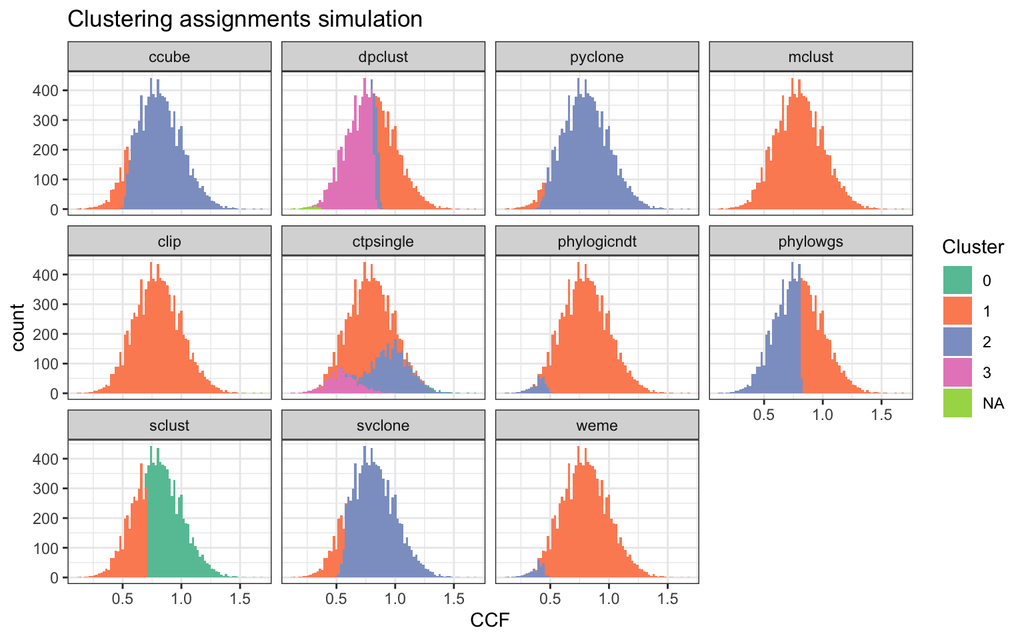

[figure not shown]

WeMe consensus

```r
df_b <- input %>%
  select(
    CCF,
    ccube_clusters,
    dpclust_clusters,
    pyclone_res,
    mclust_res,
    clip_res,
    ctp_res,
    phylogic_res,
    wgs_res,
    sclust_res,
    svclone_res,
    consensus_cluster) %>%
  rename(
    weme = consensus_cluster,
    pyclone = pyclone_res,
    ccube = ccube_clusters,
    dpclust = dpclust_clusters,
    mclust = mclust_res,
    clip = clip_res,
    ctpsingle = ctp_res,
    phylogicndt = phylogic_res,
    phylowgs = wgs_res,
    sclust = sclust_res,
    svclone = svclone_res
    ) %>%
  reshape2::melt(id.vars = "CCF")

# Plot
pfin <- ggplot(df_b,
       aes(x = CCF, fill = value %>% paste())
       ) +
  geom_histogram(binwidth = 0.02) +
  scale_fill_brewer("Cluster", palette = "Set2") +
  facet_wrap(.~variable, nrow = 3) +
  theme_bw() + ggtitle("Clustering assignments simulation")

pfin %>%  ggsave("all_consensus_plot.png", plot = ., units = "px", width = 1800, height = 1800)

pfin
```

## Multiple simulations (generalisation)

We provide code to reproduce the actual simulations with more replicates (not run here):

```bash
Rscript run_simulation.R
```

This will generate $50$ folders named `sim_[1-NREPS]` with all the inputs and results, together with file `p_sim.rds` to plot panel a-b Supplementary Figure 2.